# TP PRICE PREDICTION GROUPE 06

### Nous observons ici dans un prémier temps qu'il y'a des valeur êtreme et si nous devons entrainer notre modèle sans les supprimmer les métriques d'évaluation de notre modèle seront

1. Médiane de l'erreur absolue (Median Absolute Error - MedAE)
2. Moyenne tronquée de l'erreur absolue (Trimmed Mean Absolute Error - TMAE)
3. Coefficient de détermination (R²)
4. Erreur absolue moyenne (Mean Absolute Error - MAE)

```python
num_outliers = data.loc[(data['Price'] > 38) | (data['Price'] < 5) ]
num_outliers = num_outliers.shape[0]
num_outliers
```

```
33
```

```python
# Pourcentage des outliers dans notre jeux de données
outliers_percentage = round((num_outliers / data.shape[0]) *100,2)
f'{outliers_percentage}% de valeur aberrantes'
```

```
'6.52% de valeur aberrantes'
```

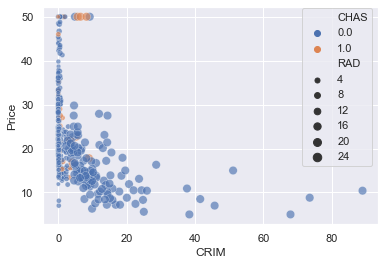

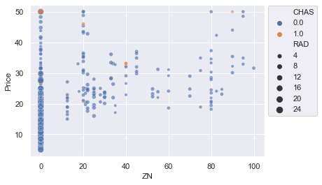

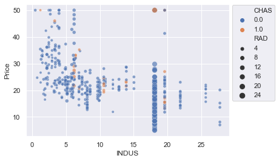

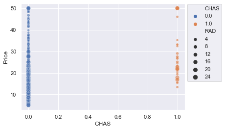

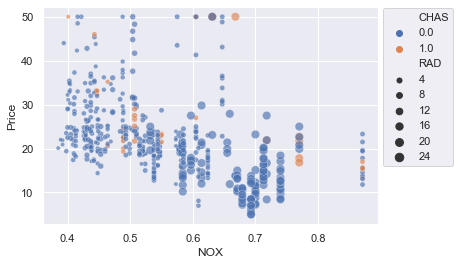

```python
col1 = ['CRIM', 'ZN', 'INDUS', 'CHAS', 'NOX']

for col in col1:
    sns.scatterplot(data=data,x=col,y='Price',hue='CHAS',size='RAD',markers='x',alpha=0.65)
    sns.set_palette('dark')
    sns.set_theme()
    plt.legend(bbox_to_anchor=(1, 1.02))
    plt.show()
```

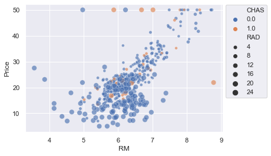

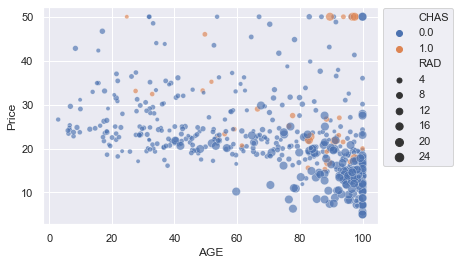

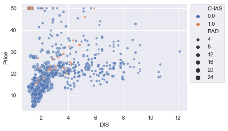

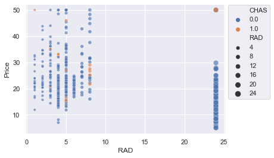

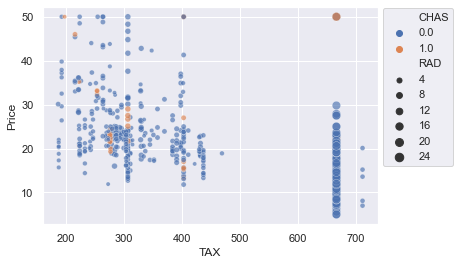

```python
col2 = ['RM', 'AGE', 'DIS', 'RAD', 'TAX']

for col in col2:
    sns.scatterplot(data=data,x=col,y='Price',hue='CHAS',size='RAD',markers='x',alpha=0.65)
    sns.set_palette('dark')
    sns.set_theme()
    plt.legend(bbox_to_anchor=(1, 1.02))
    plt.show()
```

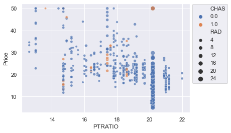

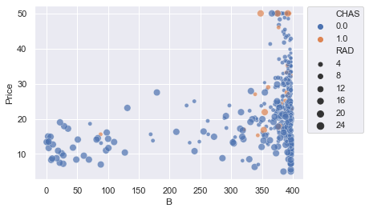

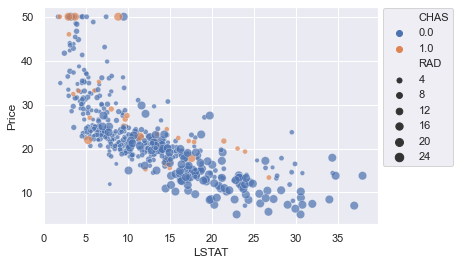

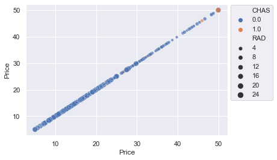

```python
col3 = ['PTRATIO', 'B', 'LSTAT', 'Price']

for col in col3:
    sns.scatterplot(data=data,x=col,y='Price',hue='CHAS',size='RAD',markers='x',alpha=0.7)
    sns.set_palette('dark')
    sns.set_theme()
    plt.legend(bbox_to_anchor=(1, 1.02))
    plt.show()
```

# 3.SELECTION DES VARIABLES

### Pour determiner les variables nous allons étudier les relation etre ellnous allons calculer la correlation, la covariance , la correlation multiple(entre 2 variables différent de Price)

```
Vérifions si dans le  DataSet nous avons des corrélation entre nos variables...
```

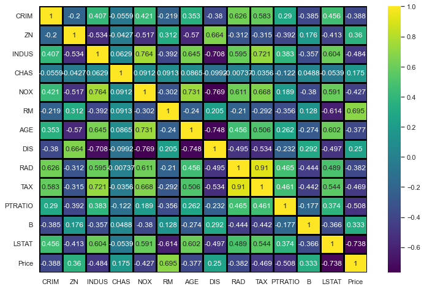

```python
# Traçons un heatmap pour afficher les corrélation entre nos différentes variables
corr = data.corr()
print('Vérifions si dans le  DataSet nous avons des corrélation entre nos variables...\n')

plt.figure(figsize=(12,8))
sns.heatmap(corr, cbar=True, yticklabels=True, cmap='viridis',annot=True,linewidths=3,
            fmt='0.3g',linecolor='black',
           )
plt.show()
```

```python
#J'affiche les variables qui influence plus le prix dans notre jeux de données
price_corr = abs(corr['Price'].sort_values(ascending=False))
price_corr = price_corr[price_corr >= 0.38]

print('Correlation of "price" with other variables:\n')
print(price_corr)
```

```
Correlation of "price" with other variables:

Price      1.000000
RM         0.695360
RAD        0.381626
CRIM       0.388305
NOX        0.427321
TAX        0.468536
INDUS      0.483725
PTRATIO    0.507787
LSTAT      0.737663
Name: Price, dtype: float64
```

#### Covariance des variables par rapport a Price

```python
cov=data.cov()
print(type(cov))
cov['Price']
```

```
<class 'pandas.core.frame.DataFrame'>
```

```
CRIM       -30.718508
ZN          77.315176
INDUS      -30.520823
CHAS         0.409409
NOX         -0.455412
RM           4.493446
AGE        -97.589017
DIS          4.840229
RAD        -30.561228
TAX       -726.255716
PTRATIO    -10.110657
B          279.989834
LSTAT      -48.447538
Price       84.586724
Name: Price, dtype: float64
```

#### Multi Correlation que nous avons detecter dans le jeu de données :

#### On considère seuille de corrélation ici a (0.7)

1. INDUS ----- NOX, DIS, TAX
2. TAX ------- INDUS, RAD
3. PTRATIO --- //
4. LSTAT ------- //
5. RM --------- //
6. NOX -------- INDUS, AGE, DIS
7. RAD -------- TAX
8. CRIM ------- //

#### Nous ne pouvons pas choisir une variable qui est foertement corréles a d'autres variables car ça ne rapport pas un plus value a l'information générale que contient le dataset

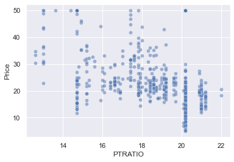

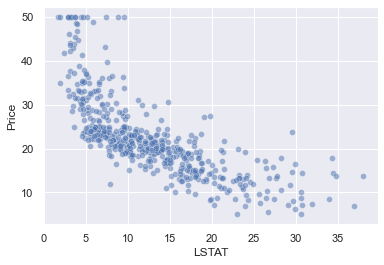

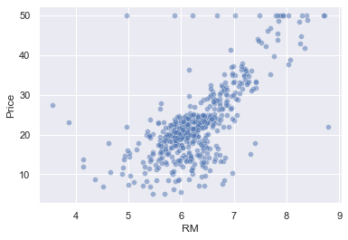

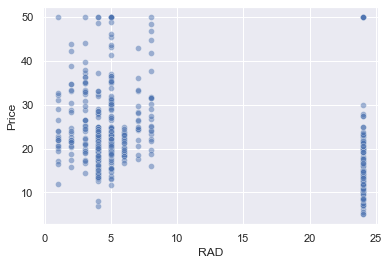

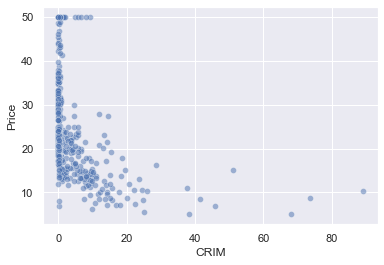

```python
selected_var = ['PTRATIO','LSTAT','RM','RAD','CRIM']
sns.set_palette('dark')
sns.set_theme()

for sel in selected_var:
    sns.scatterplot(data=data,x=sel,y='Price',markers='p',alpha=0.5)
    plt.show()
```

### En résumé, la covariance entre deux variables numériques fournit des informations sur la direction et la force de la relation entre ces variables, mais elle doit être interprétée avec prudence en tenant compte de l'échelle des variables et de ses limitations.

### Raison pour laquelle l'interprétation usuelle de la covariance ne nous donnes pas d'information trés pertinentes ici

### Nous allons utiliser les variables suivantes pour mon modèle de régression

1. PTRATIO
2. LSTAT
3. RM
4. RAD
5. CRIM